# Machine Learning Project

Ronald Thisted

2014-08-23 11:29:39

# Initial data wrangling steps

## Downloading and preprocessing the data

```r
# Download the training and test data if this hasn't been done earlier
#  (We test for this, because these commands take a while to complete)
fileUrl1 <- "https://d396qusza40orc.cloudfront.net/predmachlearn/pml-training.csv"
fileUrl2 <- "https://d396qusza40orc.cloudfront.net/predmachlearn/pml-testing.csv"
if (!file.exists("pml-training.csv")) {
        download.file(fileUrl1, dest="pml-training.csv", method="curl")
        download.file(fileUrl2, dest="pml-testing.csv", method="curl")
}
library(utils)
trainSet <- read.csv("pml-training.csv")
testSet  <- read.csv("pml-testing.csv")
```

## Data cleaning

From a preliminary look at the training data set in Excel and R, some of the variables have lots of NAs, and some have entries for only a subset of rows corresponding to `new_window=="yes"`. For these variables, the automatic reading of the .csv file puts the numeric values in quotes, so that they are read as strings rather than numerics. They can be converted back to numerics, but a key question is what to do with the `new_window` subsets. Should we consider only those rows tiwh `new_window =="no"`, as the other rows appear to be summary information of some sort?

```r
widx <- trainSet$new_window=="yes"
table(widx)
```

```
## widx
## FALSE  TRUE
## 19216   406
```

```r
x1 <- trainSet$kurtosis_roll_belt
head(summary(x1),24)
```

```
##             #DIV/0! -1.908453 -0.016850 -0.021024 -0.025513 -0.033935
##     19216        10         2         1         1         1         1
## -0.034743 -0.060160 -0.060755 -0.080411 -0.100466 -0.150950 -0.169891
##         1         1         1         1         1         1         1
## -0.185023 -0.198495 -0.210458 -0.213995 -0.220867 -0.225876 -0.229831
##         1         1         1         1         1         1         1
## -0.262387 -0.262453 -0.263059
##         1         1         1
```

```r
suppressWarnings(x2 <- as.numeric(as.character(x1)))
summary(x2)
```

```
##    Min. 1st Qu.  Median    Mean 3rd Qu.    Max.    NA's
##      -2      -1      -1       0       0      33   19226
```

```r
table(widx,!is.na(x2))
```

```
##
## widx    FALSE  TRUE
##   FALSE 19216     0
##   TRUE     10   396
```

```r
x3 <- data.frame(as.character(x1),x2)
head(x3[!is.na(x2),])
```

```
##     as.character.x1.      x2
## 24          5.587755  5.5878
## 52         -0.997130 -0.9971
## 76          7.515290  7.5153
## 165        -2.121212 -2.1212
## 210        -1.122273 -1.1223
## 241        -0.668237 -0.6682
```

Here are all of the variables that are factor variables in the training set. This means that they either are true factor variables (like `classe`), or they contain a mix of numeric and non-numeric values in Excel.

```r
mydataF<-trainSet[,sapply(trainSet,function(x)is.factor(x))]
colnames(mydataF)
```

```
##  [1] "user_name"               "cvtd_timestamp"
##  [3] "new_window"              "kurtosis_roll_belt"
##  [5] "kurtosis_picth_belt"     "kurtosis_yaw_belt"
##  [7] "skewness_roll_belt"      "skewness_roll_belt.1"
##  [9] "skewness_yaw_belt"       "max_yaw_belt"
## [11] "min_yaw_belt"            "amplitude_yaw_belt"
## [13] "kurtosis_roll_arm"       "kurtosis_picth_arm"
## [15] "kurtosis_yaw_arm"        "skewness_roll_arm"
## [17] "skewness_pitch_arm"      "skewness_yaw_arm"
## [19] "kurtosis_roll_dumbbell"  "kurtosis_picth_dumbbell"
## [21] "kurtosis_yaw_dumbbell"   "skewness_roll_dumbbell"
## [23] "skewness_pitch_dumbbell" "skewness_yaw_dumbbell"
## [25] "max_yaw_dumbbell"        "min_yaw_dumbbell"
## [27] "amplitude_yaw_dumbbell"  "kurtosis_roll_forearm"
## [29] "kurtosis_picth_forearm"  "kurtosis_yaw_forearm"
## [31] "skewness_roll_forearm"   "skewness_pitch_forearm"
## [33] "skewness_yaw_forearm"    "max_yaw_forearm"
## [35] "min_yaw_forearm"         "amplitude_yaw_forearm"
## [37] "classe"
```

Let’s try to fix them up:

```r
fixer <- function(x) {if (is.factor(x)) {x <- as.numeric(as.character(x))} else x}
options(warn=-1)
ds <- sapply(trainSet[,-c(1:6,160)],fixer)
options(warn=0)
ds <- data.frame(trainSet[,1:6],ds,classe=trainSet[,160])

# count the number of NAs (and imputed NAs from the factor conversion)
naCols <- vector(length=160)
for (i in 1:160){ naCols[i]<- sum(is.na(ds[,i]))}
table(naCols)
```

```
## naCols
##     0 19216 19217 19218 19220 19221 19225 19226 19227 19248 19293 19294
##    60    67     1     1     1     4     1     4     2     2     1     1
## 19296 19299 19300 19301 19622
##     2     1     4     2     6
```

```r
# Let's delete columns that are just these summary cols
dssub <- ds[,which(naCols < 10)]
```

## Omitting non-predictors

Since the timestamps uniquely identify occasions in the training set (but are independent of anything that will appear in the test set), they can be used to perfectly predict (in-sample) class, but are useless for out-of-sample prediction. Similary user name is not helpful for out-of-sample prediction. Using the command `table(dssub$num_window,dssub$user_name)` (output omitted), it is also clear that each window number is used only for a single user. Thus, these variables should be omitted from any prediction algorithm. These are variables 1:5 and 7 in the data set.

We also restrict the prediction model to be based on the cases for which `new_window=="no"`, which is variable number 6 in the data set. Thus, columns 8:60 are used for model building.

# Building alternative machine-learning models

We start with a simple recursive partitioning prediction model (CART), followed by $k$-nearest neighbors, random forests, and then bagged trees. We expect that the random forest model will be our final model, and most of our diagnostic steps will be focused on that model.

## CART model (recursive partitioning)

```r
set.seed(9943413)
ptm <- proc.time()
model1 <- train(classe ~ .,
                data=dssub[dssub$new_window=="no",8:60],
                method="rpart")
confusionMatrix(predict(model1),dssub$classe[dssub$new_window=="no"])
```

```
## Confusion Matrix and Statistics
##
##           Reference
## Prediction    A    B    C    D    E
##          A 4981 1551 1550 1419  516
##          B   80 1259  108  556  476
##          C  397  908 1694 1172  947
##          D    0    0    0    0    0
##          E   13    0    0    0 1589
##
## Overall Statistics
##
##                Accuracy : 0.496
##                  95% CI : (0.488, 0.503)
##     No Information Rate : 0.285
##     P-Value [Acc > NIR] : <2e-16
##
##                   Kappa : 0.341
##  Mcnemar's Test P-Value : NA
##
## Statistics by Class:
##
##                      Class: A Class: B Class: C Class: D Class: E
## Sensitivity             0.910   0.3386   0.5054    0.000   0.4504
## Specificity             0.634   0.9213   0.7842    1.000   0.9992
## Pos Pred Value          0.497   0.5079   0.3310      NaN   0.9919
## Neg Pred Value          0.947   0.8531   0.8824    0.836   0.8899
## Prevalence              0.285   0.1935   0.1744    0.164   0.1836
## Detection Rate          0.259   0.0655   0.0882    0.000   0.0827
## Detection Prevalence    0.521   0.1290   0.2663    0.000   0.0834
## Balanced Accuracy       0.772   0.6300   0.6448    0.500   0.7248
```

```r
varImp(model1)
```

```
## rpart variable importance
##
##   only 20 most important variables shown (out of 52)
##
##                   Overall
## pitch_forearm       100.0
## roll_forearm         72.8
## roll_belt            69.7
## magnet_dumbbell_y    49.1
## accel_belt_z         42.7
## magnet_belt_y        40.3
## yaw_belt             40.2
## magnet_dumbbell_z    36.1
## total_accel_belt     35.1
## magnet_arm_x         27.2
## accel_arm_x          26.4
## roll_dumbbell        18.4
## accel_dumbbell_y     15.4
## roll_arm             15.1
## accel_forearm_x       0.0
## gyros_arm_z           0.0
## magnet_forearm_y      0.0
## gyros_forearm_z       0.0
## accel_forearm_y       0.0
## magnet_belt_x         0.0
```

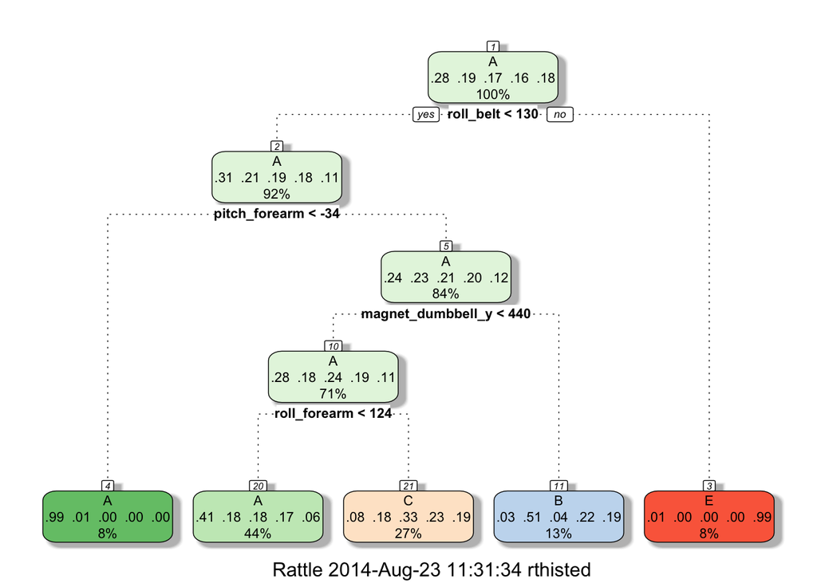

```r
fancyRpartPlot(model1$finalModel)
```

```r
t <- proc.time()-ptm
te <- t["elapsed"]
t
```

```
##    user  system elapsed
##  89.044   3.919  94.969
```

Note that no cases are classified into class D by the CART algorithm, and that we only have a combined accuracy of 0.496—not great.

Time to fit this model was 1 minutes, 34.969 seconds.

## $k$-nearest neighbor model

In the nearest-neighbor calculation, we standardize the predictors so that they are not on different scales (thereby giving each predictor an equal weight in the distance calculations).

```r
set.seed(9341355)
ptm2 <- proc.time()
model2 <- train(classe ~ .,
                data=dssub[dssub$new_window=="no",8:60],
                preProcess=c("center", "scale"),
                method="knn")
model2
```

```
## k-Nearest Neighbors
##
## 19216 samples
##    52 predictor
##     5 classes: 'A', 'B', 'C', 'D', 'E'
##
## Pre-processing: centered, scaled
## Resampling: Bootstrapped (25 reps)
##
## Summary of sample sizes: 19216, 19216, 19216, 19216, 19216, 19216, ...
##
## Resampling results across tuning parameters:
##
##   k  Accuracy  Kappa  Accuracy SD  Kappa SD
##   5  1.0       1.0    0.003        0.003
##   7  1.0       0.9    0.003        0.003
##   9  0.9       0.9    0.004        0.005
##
## Accuracy was used to select the optimal model using  the largest value.
## The final value used for the model was k = 5.
```

```r
confusionMatrix(predict(model2),dssub$classe[dssub$new_window=="no"])
```

```
## Confusion Matrix and Statistics
##
##           Reference
## Prediction    A    B    C    D    E
##          A 5461   26    1    2    1
##          B    8 3661    8    1    6
##          C    0   26 3328   43    5
##          D    1    4   14 3097    3
##          E    1    1    1    4 3513
##
## Overall Statistics
##
##                Accuracy : 0.992
##                  95% CI : (0.991, 0.993)
##     No Information Rate : 0.285
##     P-Value [Acc > NIR] : < 2e-16
##
##                   Kappa : 0.99
##  Mcnemar's Test P-Value : 4.35e-06
##
## Statistics by Class:
##
##                      Class: A Class: B Class: C Class: D Class: E
## Sensitivity             0.998    0.985    0.993    0.984    0.996
## Specificity             0.998    0.999    0.995    0.999    1.000
## Pos Pred Value          0.995    0.994    0.978    0.993    0.998
## Neg Pred Value          0.999    0.996    0.998    0.997    0.999
## Prevalence              0.285    0.193    0.174    0.164    0.184
## Detection Rate          0.284    0.191    0.173    0.161    0.183
## Detection Prevalence    0.286    0.192    0.177    0.162    0.183
## Balanced Accuracy       0.998    0.992    0.994    0.991    0.998
```

```r
varImp(model2)
```

```
## ROC curve variable importance
##
##   variables are sorted by maximum importance across the classes
##   only 20 most important variables shown (out of 52)
##
##                       A    B    C     D    E
## pitch_forearm     100.0 64.4 71.6 100.0 68.7
## roll_dumbbell      52.7 63.3 84.1  84.1 58.4
## accel_forearm_x    81.9 51.2 64.0  81.9 47.5
## magnet_arm_x       78.6 54.6 56.0  78.6 66.2
## magnet_arm_y       77.3 41.0 54.7  77.3 68.5
## accel_arm_x        74.0 52.6 48.5  74.0 62.8
## pitch_dumbbell     54.5 72.0 72.0  62.3 47.8
## magnet_forearm_x   71.9 51.2 40.7  71.9 43.9
## magnet_belt_y      68.2 60.8 62.2  62.8 68.2
## magnet_dumbbell_x  66.4 66.4 65.4  51.9 53.3
## magnet_dumbbell_y  47.3 66.2 66.2  48.7 54.0
## accel_dumbbell_x   58.5 58.5 58.5  49.4 41.6
## magnet_dumbbell_z  57.6 25.9 57.6  38.4 55.2
## magnet_arm_z       54.0 54.0 38.7  42.0 50.5
## magnet_belt_z      52.0 50.7 50.5  52.4 52.4
## pitch_arm          50.4 29.0 38.5  43.8 50.4
## roll_belt          45.9 40.8 42.8  48.4 48.4
## magnet_forearm_y   39.2 26.4 46.5  46.5 37.1
## accel_dumbbell_z   44.4 44.4 42.0  23.8 32.0
## yaw_dumbbell       21.7 42.9 42.9  20.3 29.9
```

```r
t2 <- proc.time()-ptm2
te2 <- t2["elapsed"]
t2
```

```
##    user  system elapsed
## 2054.80   20.88 2154.32
```

Note the generally good predictive performance (over 95%), and the very large amount of computation time (35 minutes, 54.323 seconds).

### Random forests

```r
set.seed(9434193)
ptm <- proc.time()
model3 <- randomForest(classe ~ .,
                       data=dssub[dssub$new_window=="no",8:60],
                       ntree=400)
model3
```

```
##
## Call:
##  randomForest(formula = classe ~ ., data = dssub[dssub$new_window ==      "no", 8:60], ntree = 400)
##                Type of random forest: classification
##                      Number of trees: 400
## No. of variables tried at each split: 7
##
##         OOB estimate of  error rate: 0.3%
## Confusion matrix:
##      A    B    C    D    E class.error
## A 5469    1    0    0    1   0.0003656
## B   10 3705    3    0    0   0.0034965
## C    0   10 3338    4    0   0.0041766
## D    0    0   23 3122    2   0.0079441
## E    0    0    0    3 3525   0.0008503
```

```r
confusionMatrix(predict(model3),dssub$classe[dssub$new_window=="no"])
```

```
## Confusion Matrix and Statistics
##
##           Reference
## Prediction    A    B    C    D    E
##          A 5469   10    0    0    0
##          B    1 3705   10    0    0
##          C    0    3 3338   23    0
##          D    0    0    4 3122    3
##          E    1    0    0    2 3525
##
## Overall Statistics
##
##                Accuracy : 0.997
##                  95% CI : (0.996, 0.998)
##     No Information Rate : 0.285
##     P-Value [Acc > NIR] : <2e-16
##
##                   Kappa : 0.996
##  Mcnemar's Test P-Value : NA
##
## Statistics by Class:
##
##                      Class: A Class: B Class: C Class: D Class: E
## Sensitivity             1.000    0.997    0.996    0.992    0.999
## Specificity             0.999    0.999    0.998    1.000    1.000
## Pos Pred Value          0.998    0.997    0.992    0.998    0.999
## Neg Pred Value          1.000    0.999    0.999    0.998    1.000
## Prevalence              0.285    0.193    0.174    0.164    0.184
## Detection Rate          0.285    0.193    0.174    0.162    0.183
## Detection Prevalence    0.285    0.193    0.175    0.163    0.184
## Balanced Accuracy       0.999    0.998    0.997    0.996    0.999
```

```r
varImp(model3)
```

```
##                      Overall
## roll_belt            1208.62
## pitch_belt            694.31
## yaw_belt              912.41
## total_accel_belt      211.06
## gyros_belt_x           93.10
## gyros_belt_y          106.22
## gyros_belt_z          301.93
## accel_belt_x          115.79
## accel_belt_y          133.77
## accel_belt_z          377.97
## magnet_belt_x         246.44
## magnet_belt_y         398.39
## magnet_belt_z         402.46
## roll_arm              320.85
## pitch_arm             160.54
## yaw_arm               235.95
## total_accel_arm       103.69
## gyros_arm_x           127.73
## gyros_arm_y           136.99
## gyros_arm_z            53.43
## accel_arm_x           217.67
## accel_arm_y           152.42
## accel_arm_z           126.26
## magnet_arm_x          262.73
## magnet_arm_y          214.00
## magnet_arm_z          183.37
## roll_dumbbell         392.79
## pitch_dumbbell        165.12
## yaw_dumbbell          251.69
## total_accel_dumbbell  263.67
## gyros_dumbbell_x      121.05
## gyros_dumbbell_y      242.58
## gyros_dumbbell_z       79.91
## accel_dumbbell_x      255.74
## accel_dumbbell_y      405.63
## accel_dumbbell_z      330.43
## magnet_dumbbell_x     474.92
## magnet_dumbbell_y     675.57
## magnet_dumbbell_z     741.60
## roll_forearm          608.65
## pitch_forearm         753.30
## yaw_forearm           170.16
## total_accel_forearm   107.58
## gyros_forearm_x        72.71
## gyros_forearm_y       123.50
## gyros_forearm_z        79.01
## accel_forearm_x       311.07
## accel_forearm_y       137.53
## accel_forearm_z       230.32
## magnet_forearm_x      206.99
## magnet_forearm_y      211.51
## magnet_forearm_z      278.83
```

```r
# get order of importance
idx <- order(-varImp(model3))
foo<-varImp(model3)[idx,]
bar <- data.frame(var=attributes(varImp(model3))$row.names[idx], foo)
head(bar, 30)
```

```
##                     var    foo
## 1             roll_belt 1208.6
## 2              yaw_belt  912.4
## 3         pitch_forearm  753.3
## 4     magnet_dumbbell_z  741.6
## 5            pitch_belt  694.3
## 6     magnet_dumbbell_y  675.6
## 7          roll_forearm  608.7
## 8     magnet_dumbbell_x  474.9
## 9      accel_dumbbell_y  405.6
## 10        magnet_belt_z  402.5
## 11        magnet_belt_y  398.4
## 12        roll_dumbbell  392.8
## 13         accel_belt_z  378.0
## 14     accel_dumbbell_z  330.4
```

[output cut: 16 more lines]

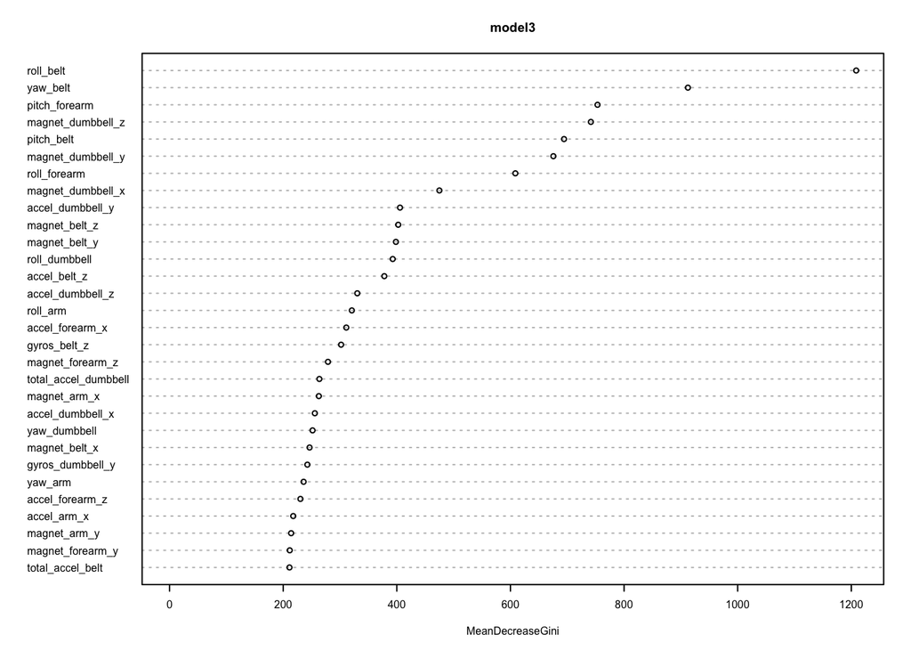

```r
varImpPlot(model3, cex=0.5)
```

```r
t <- proc.time()-ptm
te <- t["elapsed"]
t
```

```
##    user  system elapsed
##   56.30    0.76   58.12
```

In-sample prediction is very good—over 99%.

Elapsed computation time (0 minutes 58.118 seconds) is much more reasonable.

### Bagged trees

Just to see if an alternative approach (bootstrap aggregation of trees) without randomized selection of variables at each stage does as well as random forests, we also fit a bagged-tree model.

```r
set.seed(478881)
ptm4 <- proc.time()
options(warn=-1)
model4 <- train(classe ~ .,
                data=dssub[dssub$new_window=="no",8:60],
                method="treebag")
model4
```

```
## Bagged CART
##
## 19216 samples
##    52 predictor
##     5 classes: 'A', 'B', 'C', 'D', 'E'
##
## No pre-processing
## Resampling: Bootstrapped (25 reps)
##
## Summary of sample sizes: 19216, 19216, 19216, 19216, 19216, 19216, ...
##
## Resampling results
##
##   Accuracy  Kappa  Accuracy SD  Kappa SD
##   1         1      0.004        0.005
##
##
```

```r
options(warn=0)
confusionMatrix(predict(model4),dssub$classe[dssub$new_window=="no"])
```

```
## Confusion Matrix and Statistics
##
##           Reference
## Prediction    A    B    C    D    E
##          A 5470    1    0    0    0
##          B    0 3716    0    0    0
##          C    1    1 3351    3    0
##          D    0    0    1 3144    0
##          E    0    0    0    0 3528
##
## Overall Statistics
##
##                Accuracy : 1
##                  95% CI : (0.999, 1)
##     No Information Rate : 0.285
##     P-Value [Acc > NIR] : <2e-16
##
##                   Kappa : 1
##  Mcnemar's Test P-Value : NA
##
## Statistics by Class:
##
##                      Class: A Class: B Class: C Class: D Class: E
## Sensitivity             1.000    0.999    1.000    0.999    1.000
## Specificity             1.000    1.000    1.000    1.000    1.000
## Pos Pred Value          1.000    1.000    0.999    1.000    1.000
## Neg Pred Value          1.000    1.000    1.000    1.000    1.000
## Prevalence              0.285    0.193    0.174    0.164    0.184
## Detection Rate          0.285    0.193    0.174    0.164    0.184
## Detection Prevalence    0.285    0.193    0.175    0.164    0.184
## Balanced Accuracy       1.000    1.000    1.000    0.999    1.000
```

```r
varImp(model4)
```

```
## treebag variable importance
##
##   only 20 most important variables shown (out of 52)
##
##                   Overall
## roll_belt           100.0
## yaw_belt             86.9
## pitch_belt           77.0
## pitch_forearm        74.4
## roll_forearm         64.8
## magnet_dumbbell_z    60.9
## magnet_dumbbell_y    59.1
## accel_dumbbell_y     57.3
## roll_dumbbell        42.8
## magnet_belt_y        36.4
## accel_belt_z         36.2
## magnet_belt_z        32.1
## magnet_dumbbell_x    31.2
## yaw_arm              30.4
## accel_forearm_x      30.1
## accel_dumbbell_z     28.9
## magnet_forearm_z     27.7
## gyros_belt_z         26.3
## accel_arm_x          22.6
## magnet_belt_x        21.7
```

```r
t4 <- proc.time()-ptm4
te4 <- t4["elapsed"]
t4
```

```
##    user  system elapsed
## 2373.85   68.01 2536.10
```

Elapsed computation time (42 minutes 16.095 seconds).

### Model comparisons

```r
predictionSet <- data.frame(m1=predict(model1, newdata=testSet), m2=predict(model2, newdata=testSet), m3=predict(model3, newdata=testSet),m4=predict(model4, newdata=testSet))
predictionSet
```

```
##    m1 m2 m3 m4
## 1   C  B  B  B
## 2   A  A  A  A
## 3   C  A  B  B
## 4   A  A  A  A
## 5   A  A  A  A
## 6   C  E  E  E
## 7   C  D  D  D
## 8   A  B  B  B
## 9   A  A  A  A
## 10  A  A  A  A
## 11  C  D  B  B
## 12  C  C  C  C
## 13  C  B  B  B
## 14  A  A  A  A
## 15  C  E  E  E
## 16  A  E  E  E
## 17  A  A  A  A
## 18  A  B  B  B
## 19  A  B  B  B
## 20  C  B  B  B
```

### Build prediction vector for submission part

```r
answers <- as.character(predictionSet$m3)
pml_write_files = function(x){
  n = length(x)
  for(i in 1:n){
    filename = paste0("problem_id_",i,".txt")
    write.table(x[i],file=filename,quote=FALSE,row.names=FALSE,col.names=FALSE)
  }
}
cwd <- getwd()
setwd("./Submissions")
pml_write_files(answers)
setwd(cwd)
```

# Model selection

## Out of sample error for random forest model

The calculations below show out-of-bag (OOB) error rates for random forests built on varying number of trees. The error rates are shown for each class, as well as an overall (averaged) out-of-bag error rate. The final model above was calculated using 400 trees, by which time the error rate has stabilized; indeed, 200 trees probably suffices.

```r
ntreelist=c(1,2,5,10,30,100,200,300,400)
cbind(ntree=ntreelist,round(model3$err.rate[ntreelist,],6))
```

```
##       ntree      OOB        A        B        C        D        E
##  [1,]     1 0.061606 0.032387 0.093931 0.090238 0.060449 0.046404
##  [2,]     2 0.059854 0.033119 0.079839 0.085117 0.070866 0.046490
##  [3,]     5 0.054289 0.033562 0.069851 0.076356 0.067021 0.038098
##  [4,]    10 0.030813 0.017391 0.043774 0.041166 0.038486 0.021210
##  [5,]    30 0.007129 0.001828 0.009683 0.011933 0.012393 0.003401
##  [6,]   100 0.003383 0.000183 0.004572 0.004177 0.008262 0.001984
##  [7,]   200 0.002966 0.000183 0.003765 0.003878 0.007944 0.001134
##  [8,]   300 0.002966 0.000366 0.003497 0.003580 0.008262 0.001134
##  [9,]   400 0.002966 0.000366 0.003497 0.004177 0.007944 0.000850
```

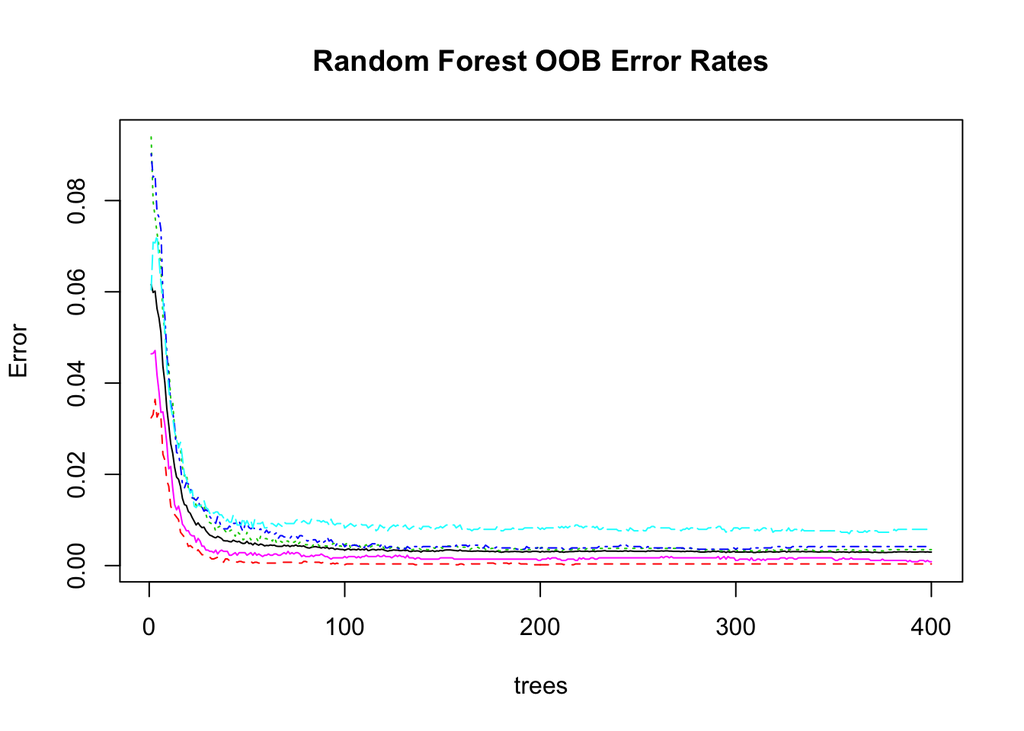

```r
plot(model3, main="Random Forest OOB Error Rates")
```

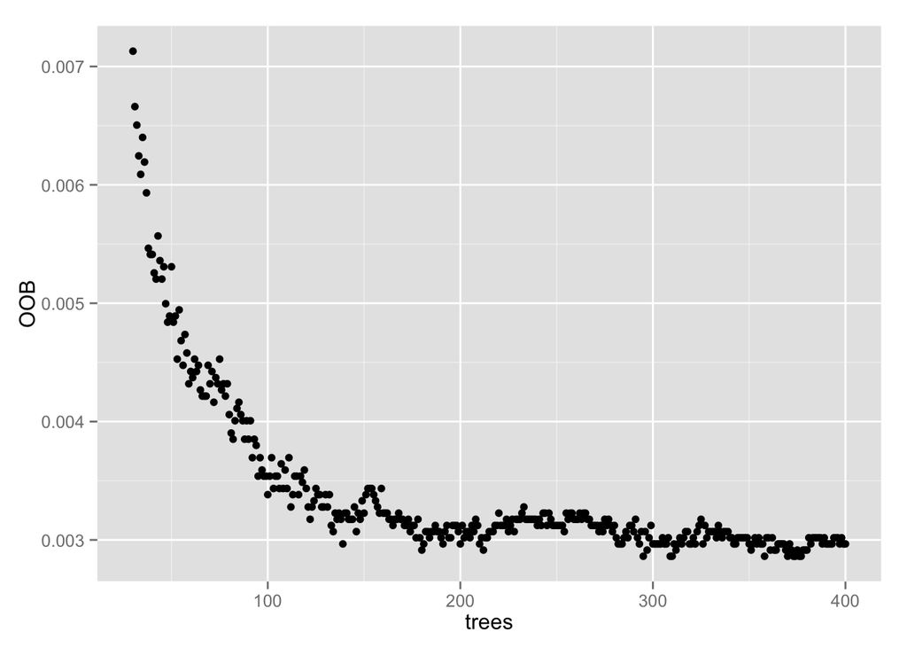

```r
qplot(trees, OOB,data=as.data.frame(cbind(trees=1:400,model3$err.rate))[30:400,])
```

## Cross validation for random forest model

The random forest algorithm uses cross validation as an intrinsic component of its tree-building, so in some sense, cross validation has already been done.

To get some idea of the effect of number of variables used to construct the random forest, we looked at a 40% sample of the training set and did cross validation.

```r
set.seed(788481)
ptm <- proc.time()
temp <- dssub[dssub$new_window=="no",8:60]
# split up training set
tempy <- temp[,53]
inTrain <- createDataPartition(tempy, p=0.4, list=F)
newTrain <- temp[ inTrain,]
newTest  <- temp[-inTrain,]
rfcvRep <- rfcv(newTrain[,-53], newTrain[,53])
rfcvRep$error.cv
```

```
##      52      26      13       6       3       1
## 0.01652 0.01678 0.02042 0.06360 0.16972 0.60931
```

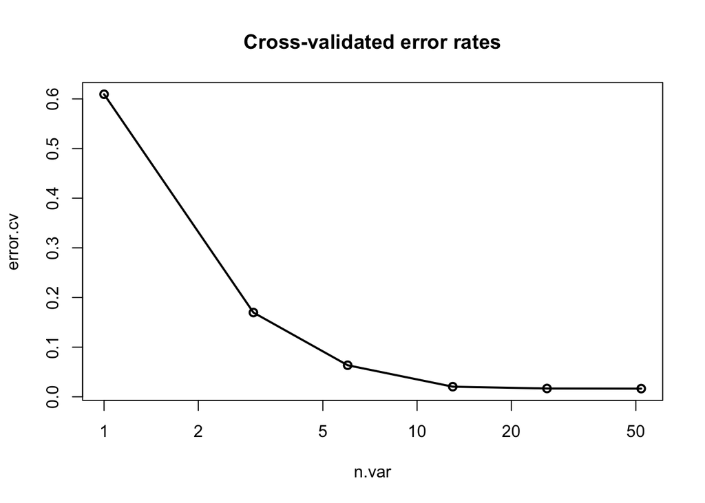

```r
with(rfcvRep,
     plot(n.var, error.cv, log="x", type="o",
          lwd=2, main="Cross-validated error rates"))
```

```r
t <- proc.time()-ptm
te <- t["elapsed"]
t
```

```
##    user  system elapsed
## 370.680   1.804 407.394
```

## Accuracy of OOB error-rate predictions

To show that the OOB error rates are good forecasts of (new) out-of-sample error rates, I split the training data set into two pieces: a 40% sample on which I ran the random forest procedure and the remaining 60% of the original training set to use as a “test set” with known true classes that I will use to validate the error-rate estimates.

Although for some classes the actual error rates are as much as twice the predicted rates, the overall accuracy corresponds closely to the actual error rates observed in the held-out sample.

```r
set.seed(487881)
ptm <- proc.time()
model3a <- randomForest(classe ~ .,
                       data=newTrain,
                       ntree=400)

# obtain OOB error rates to estimate out-of-sample error rates
ntreelist=c(100,200,300,400)
cbind(ntree=ntreelist,round(model3a$err.rate[ntreelist,],6))
```

```
##      ntree     OOB        A       B       C       D        E
## [1,]   100 0.01431 0.004568 0.02083 0.01864 0.02780 0.006374
## [2,]   200 0.01158 0.004111 0.01747 0.01491 0.02065 0.005666
## [3,]   300 0.01093 0.004568 0.01613 0.01268 0.02224 0.003541
## [4,]   400 0.01093 0.004111 0.01546 0.01268 0.02383 0.003541
```

```r
pred <- predict(model3a,newTest)

# see how well actual misclassification rates compare
ttc <- table(pred,newTest$classe)
ttc
```

```
##
## pred    A    B    C    D    E
##    A 3265   20    0    5    0
##    B   15 2193   28    0    0
##    C    2   17 1979   30    6
##    D    0    0    4 1846    5
##    E    0    0    0    7 2105
```

```r
# class-wise error rates held-out test set
tt <- confusionMatrix(pred,newTest$classe)
error.rates <- c(1-tt$overall[1],1-tt$byClass[,3])
names(error.rates)[1] <- "Overall"
round(error.rates,6)
```

```
##  Overall Class: A Class: B Class: C Class: D Class: E
## 0.012059 0.007599 0.019231 0.027040 0.004852 0.003314
```

```r
# compare actual with predicted
error.compare <- rbind(error.rates,model3a$err.rate[400,])
rownames(error.compare) <- c("actual", "predicted")
error.compare
```

```
##           Overall Class: A Class: B Class: C Class: D Class: E
## actual    0.01206 0.007599  0.01923  0.02704 0.004852 0.003314
## predicted 0.01092 0.004111  0.01546  0.01268 0.023828 0.003541
```

```r
t <- proc.time()-ptm
te <- t["elapsed"]
t
```

```
##    user  system elapsed
##  19.814   0.324  20.334
```

## Session information

It is useful to record a bit of information about the environment that was in place when the document above was produced.

```r
Sys.time()
```

```
## [1] "2014-08-23 13:01:04 CDT"
```

```r
ttot <- proc.time()-ptmtot
tetot<- ttot["elapsed"]
```

Total elapsed time was 91 minutes 19.088 seconds.